# Evolution of growth rate distributions

Examine how the distribution of a sum of independent and identically distributed random variables changes with the number of variables being added. For Laplace variables, calculate the density of the sum analytically; for symmetric Weibull variables, estimate it by simulation. Also plot the conditional distribution of a ratio given a fixed sum of positive Weibull variables.

## 1 Convolution: Laplace and Weibull tails

Let $\widetilde{S}_n=\sum_{k=1}^n X_k$ be the sum of independent and identically distributed random variables $X_1,\ldots,X_n$. Compare density changes under convolution for $n=1,\ldots,12$.

```r
library(tidyverse)
library(hrbrthemes)
theme_set(theme_ipsum(base_size = 12, axis_title_size = 13))
```

**Laplace**

Consider a Laplace distribution with mean zero and scale parameter one. Its variance is two, and the density of the sum of $n$ independent variables can be calculated using the following analytical expression.

$$f_{\sum_{k=1}^n X_k}(x)=\frac{e^{-|x|}}{(n-1)!2^n} \sum_{j=0}^{n-1} \frac{(n-1+j)!}{(n-1-j)!j!} \frac{|x|^{n-1-j}}{2^j}, \quad x \in \mathbb{R}$$

```r
set.seed(1234)

library(data.table)
library(latex2exp)

my_func <- \(x, n) {
  summation <- 0
  for (j in 0:(n-1)) {
    term <- factorial(n-1+j) / (factorial(n-1-j) * factorial(j)) * (abs(x)^(n-1-j)) / (2^j)
    summation <- summation + term
  }
  exp(-abs(x))/(factorial(n-1)*2^n)*summation
}
```

Overlay density curves for $n=1,\ldots,12$, displaying them with a linear and a logarithmic vertical scale. In the logarithmic-scale figure, overlay the normal distribution $N(0,24)$, which has the same mean and variance as the sum of 12 variables.

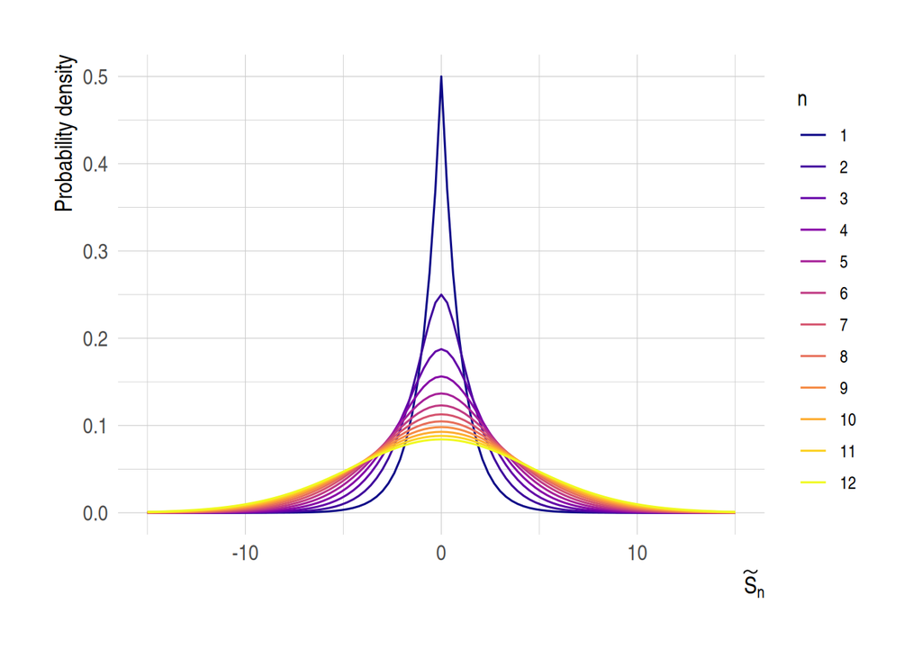

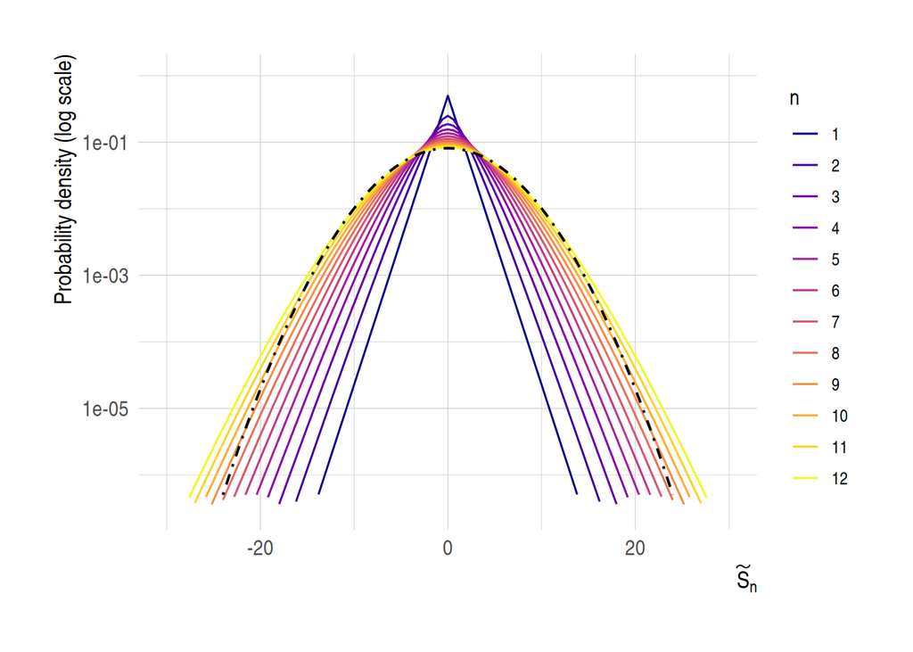

```r
Laplace_plot <- ggplot() +
  map(1:12, ~ geom_function(fun = \(x) my_func(x, .x),
                            aes(color = factor(.x, levels = as.character(1:12)))
                            )) +
  scale_color_viridis_d(option = "C") +
  theme(axis.title = element_text(face = "bold"))

Laplace_plot +
  labs(x = TeX("$\\widetilde{S}_n$"),
       y = "Probability density",
       color = TeX("$n$")
       ) +
  xlim(-15,15)
ggsave(filename = "Laplace_sum.png", path = "graph")

Laplace_plot +
  geom_function(fun = \(x) dnorm(x, sd = sqrt(2)*sqrt(12)), size = 0.7, linetype = "dotdash") +
  labs(x = TeX("$\\widetilde{S}_n$"),
       y = "Probability density (log scale)",
       color = TeX("$n$")
       ) +
  xlim(-30,30) +
  scale_y_log10(limits = c(10^{-6.5},1))
ggsave(filename = "Laplace_sum_log.png", path = "graph")
```

**Weibull**

Generate a symmetric distribution with mean zero by independently assigning positive and negative signs, each with probability $1/2$, to Weibull draws with shape parameter $\alpha=0.7$ and scale parameter one. Its right tail is represented by the following survival function.

$$\mathbb{P}(X_k>x)=\frac{1}{2}\exp(-x^\alpha), \quad x\geq0,\quad \alpha=0.7.$$

Calculate cumulative sums and compare the distributions of the sums across periods.

```r
m <- 10^7   # number of firm
years <- 12  # number of years per group
n <- m*years # total number of obs

# use data.table for faster manipulation
weibull_tb <-
  data.table(
    id = rep(1:m, each = years),
    year = rep(1:years, m),
    x = rweibull(n, shape = 0.7)*ifelse(rbinom(n, 1, 0.5) == 1, 1, -1)
  )

# calc cumulative sums efficiently by group
weibull_tb[, sum_x := cumsum(x), by = id]
```

Estimate kernel densities separately for each period. Since the variance of a symmetric Weibull variable is $\Gamma(1+2/\alpha)$, overlay the normal distribution $N(0,12\Gamma(1+2/0.7))$ corresponding to the sum of 12 variables in the logarithmic-scale figure.

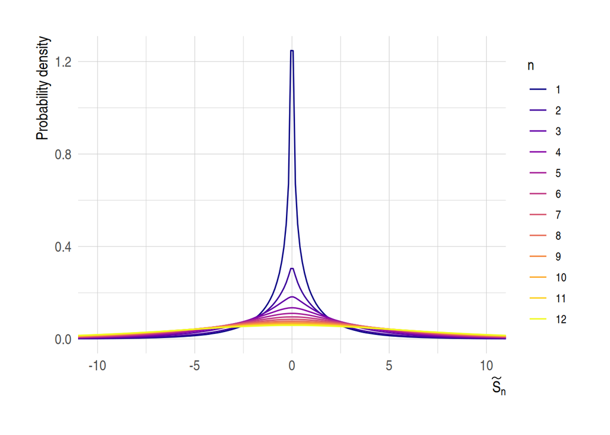

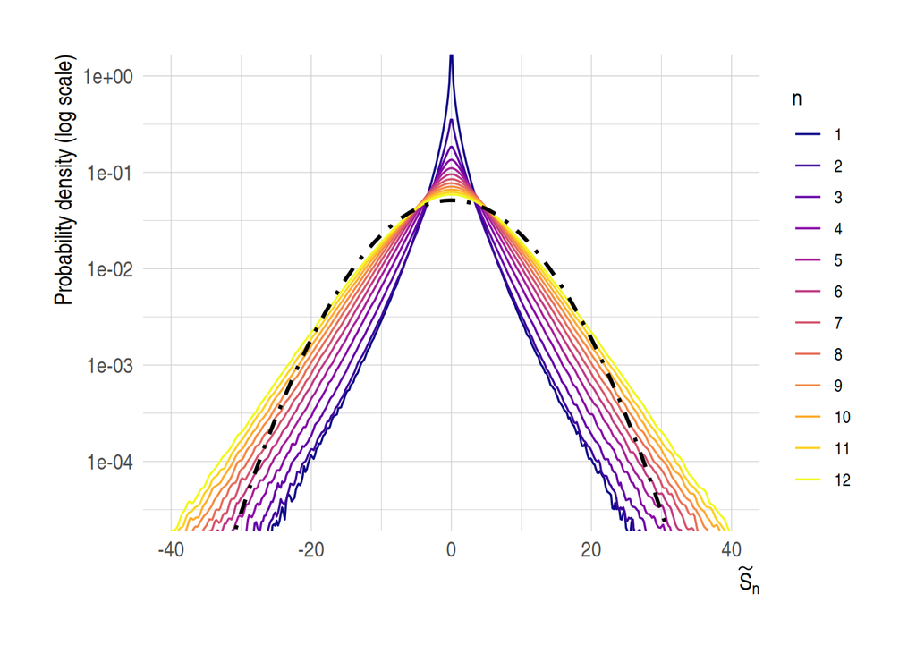

```r
weibull_tb |>
  filter(abs(sum_x) < 30) |>
  mutate(year = factor(year, levels = 1:12)) |>
ggplot(aes(sum_x, color = year)) +
  geom_line(stat = "density", aes(y = after_stat(density))) +
  scale_color_viridis_d(option = "C") +
  labs(x = TeX("$\\widetilde{S}_n$"),
       y = "Probability density",
       color = TeX("$n$")
       ) +
  theme(axis.title = element_text(face = "bold")) +
  coord_cartesian(xlim = c(-10, 10))
ggsave(filename = "Weibull_sum.png", path = "graph")

weibull_tb |>
  filter(abs(sum_x) < 50) |>
  mutate(year = factor(year, levels = 1:12)) |>
ggplot(aes(sum_x, color = year)) +
  geom_line(stat = "density", aes(y = after_stat(density))) +
  geom_function(fun = \(x) dnorm(x, sd = sqrt(12 * gamma(1 + 2 / 0.7))),
                size = 1.0, linetype = "dotdash", color = "black") +
  scale_color_viridis_d(option = "C") +
  labs(x = TeX("$\\widetilde{S}_n$"),
       y = "Probability density (log scale)",
       color = TeX("$n$")
       ) +
  theme(axis.title = element_text(face = "bold")) +
  scale_y_log10() +
  coord_cartesian(xlim = c(-40, 40), ylim = c(10^{-4.5}, 1.0))
ggsave(filename = "Weibull_sum_log.png", path = "graph")
```

## 2 Weibull: conditional ratio distribution

Here, consider independent positive Weibull variables $\xi_1,\xi_2$. Let both variables have shape parameter $\alpha$ and scale parameter one. Examine the conditional density of the ratio $Z=\xi_1/(\xi_1+\xi_2)$ given the fixed sum $\xi_1+\xi_2=d$. Then $0<z<1$, and the density can be expressed as follows using a normalizing constant $C>0$.

$$f(z) = C (z(1 - z))^{\alpha - 1} \exp (- d^\alpha (z^\alpha + (1 - z)^\alpha))$$

Fix the sum at $d=2$ and evaluate the integral over $0<z<1$ for each of $\alpha=0.7,1,2$. The constant $C$ is the reciprocal of each integral.

```r
ratio_f <- \(z, alpha = 0.7, d = 2.0) (z*(1 - z))^(alpha - 1)*exp(-d^alpha*(z^alpha + (1 - z)^alpha))
ratio_d <- 2.0
ratio_normalizers <- map_dbl(
  c("0.7" = 0.7, "1.0" = 1.0, "2.0" = 2.0),
  \(alpha) integrate(ratio_f, lower = 0, upper = 1, alpha = alpha, d = ratio_d)$value
)
ratio_normalizers
```

```
       0.7        1.0        2.0
0.29067337 0.13533528 0.01632285
```

Normalize each function to a probability density by dividing by its corresponding integral, and compare the three curves.

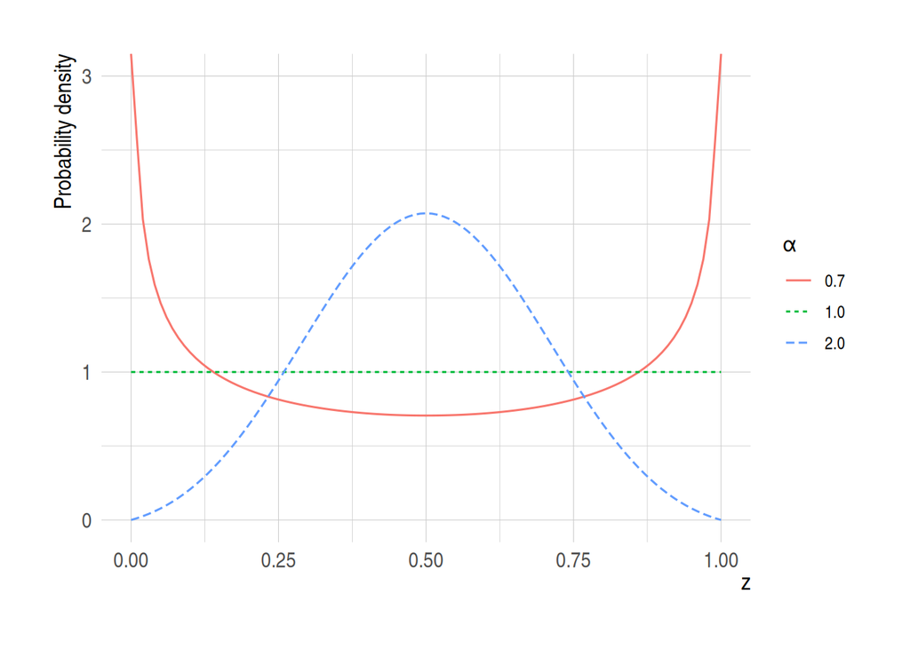

```r
ggplot() +
  geom_function(fun = ~ ratio_f(., alpha = 0.7, d = ratio_d)/ratio_normalizers[["0.7"]],
                aes(color = "0.7", linetype = "0.7")) +
  geom_function(fun = ~ ratio_f(., alpha = 1.0, d = ratio_d)/ratio_normalizers[["1.0"]],
                aes(color = "1.0", linetype = "1.0")) +
  geom_function(fun = ~ ratio_f(., alpha = 2.0, d = ratio_d)/ratio_normalizers[["2.0"]],
                aes(color = "2.0", linetype = "2.0")) +
  ylim(c(0, 3.0)) +
  labs(x = TeX("$z$"),
       y = "Probability density",
       color = TeX("$\\alpha$"), linetype = TeX("$\\alpha$")) +
  theme(axis.title = element_text(face = "bold"))
ggsave(filename = "Weibull_alpha.png", path = "graph")
```